# Data Assessment

### Cleaning Data and removing null values

```python
#checking the null values
canada.isnull().values.any()
```

```
True
```

```python
canada.fillna( method ='ffill', inplace = True)
```

```python
canada.isnull()
```

|  | Unnamed: 0 | year | total_dwelling | single_detached | multiple | semi_detached | row | apartment | total_dwelling_market | homeownership_freehold | ... | one_bedroom | two_bedroom | three_bedroom | population | labour_participation_rate | employment_change | unemployment_rate | disposable_income_change | migration | region |
| --- | --- | --- | --- | --- | --- | --- | --- | --- | --- | --- | --- | --- | --- | --- | --- | --- | --- | --- | --- | --- | --- |
| 0 | False | False | False | False | False | False | False | False | False | False | ... | False | False | False | False | False | False | False | False | False | False |
| 1 | False | False | False | False | False | False | False | False | False | False | ... | False | False | False | False | False | False | False | False | False | False |
| 2 | False | False | False | False | False | False | False | False | False | False | ... | False | False | False | False | False | False | False | False | False | False |
| 3 | False | False | False | False | False | False | False | False | False | False | ... | False | False | False | False | False | False | False | False | False | False |
| 4 | False | False | False | False | False | False | False | False | False | False | ... | False | False | False | False | False | False | False | False | False | False |
| ... | ... | ... | ... | ... | ... | ... | ... | ... | ... | ... | ... | ... | ... | ... | ... | ... | ... | ... | ... | ... | ... |
| 939 | False | False | False | False | False | False | False | False | False | False | ... | False | False | False | False | False | False | False | False | False | False |
| 940 | False | False | False | False | False | False | False | False | False | False | ... | False | False | False | False | False | False | False | False | False | False |
| 941 | False | False | False | False | False | False | False | False | False | False | ... | False | False | False | False | False | False | False | False | False | False |
| 942 | False | False | False | False | False | False | False | False | False | False | ... | False | False | False | False | False | False | False | False | False | False |
| 943 | False | False | False | False | False | False | False | False | False | False | ... | False | False | False | False | False | False | False | False | False | False |

944 rows × 38 columns

```python
canada_clean = canada.dropna(how='all', axis=1)
canada_clean.head()
```

|  | Unnamed: 0 | year | total_dwelling | single_detached | multiple | semi_detached | row | apartment | total_dwelling_market | homeownership_freehold | ... | one_bedroom | two_bedroom | three_bedroom | population | labour_participation_rate | employment_change | unemployment_rate | disposable_income_change | migration | region |
| --- | --- | --- | --- | --- | --- | --- | --- | --- | --- | --- | --- | --- | --- | --- | --- | --- | --- | --- | --- | --- | --- |
| 0 | 0 | 1990.0 | 3297 | 2847 | 450 | 57 | 6 | 387 | 2274 | 2004.0 | ... | 418 | 524 | 608 | 1105.421 | 67.300 | 0.219444 | 7.4 | -2.669133 | -5108 | manitoba |
| 1 | 1 | 1991.0 | 1950 | 1589 | 361 | 14 | 0 | 347 | 1438 | 1085.0 | ... | 424 | 531 | 630 | 1109.604 | 67.025 | -1.364064 | 8.6 | -2.669133 | -5108 | manitoba |
| 2 | 2 | 1992.0 | 2310 | 1683 | 627 | 64 | 10 | 553 | 1821 | 1383.0 | ... | 434 | 545 | 644 | 1112.689 | 66.475 | -1.351685 | 9.3 | -0.326989 | -5108 | manitoba |
| 3 | 3 | 1993.0 | 2425 | 1874 | 551 | 52 | 83 | 416 | 1702 | 1338.0 | ... | 435 | 550 | 652 | 1117.618 | 66.850 | 0.766782 | 9.3 | -0.453243 | -2520 | manitoba |
| 4 | 4 | 1994.0 | 3197 | 2441 | 756 | 72 | 410 | 274 | 1664 | 1289.0 | ... | 440 | 551 | 645 | 1123.230 | 66.750 | 0.774181 | 8.8 | 0.161821 | -1996 | manitoba |

5 rows × 38 columns

```python
canada_clean.isnull()
```

|  | Unnamed: 0 | year | total_dwelling | single_detached | multiple | semi_detached | row | apartment | total_dwelling_market | homeownership_freehold | ... | one_bedroom | two_bedroom | three_bedroom | population | labour_participation_rate | employment_change | unemployment_rate | disposable_income_change | migration | region |
| --- | --- | --- | --- | --- | --- | --- | --- | --- | --- | --- | --- | --- | --- | --- | --- | --- | --- | --- | --- | --- | --- |
| 0 | False | False | False | False | False | False | False | False | False | False | ... | False | False | False | False | False | False | False | False | False | False |
| 1 | False | False | False | False | False | False | False | False | False | False | ... | False | False | False | False | False | False | False | False | False | False |
| 2 | False | False | False | False | False | False | False | False | False | False | ... | False | False | False | False | False | False | False | False | False | False |
| 3 | False | False | False | False | False | False | False | False | False | False | ... | False | False | False | False | False | False | False | False | False | False |
| 4 | False | False | False | False | False | False | False | False | False | False | ... | False | False | False | False | False | False | False | False | False | False |
| ... | ... | ... | ... | ... | ... | ... | ... | ... | ... | ... | ... | ... | ... | ... | ... | ... | ... | ... | ... | ... | ... |
| 939 | False | False | False | False | False | False | False | False | False | False | ... | False | False | False | False | False | False | False | False | False | False |
| 940 | False | False | False | False | False | False | False | False | False | False | ... | False | False | False | False | False | False | False | False | False | False |
| 941 | False | False | False | False | False | False | False | False | False | False | ... | False | False | False | False | False | False | False | False | False | False |
| 942 | False | False | False | False | False | False | False | False | False | False | ... | False | False | False | False | False | False | False | False | False | False |
| 943 | False | False | False | False | False | False | False | False | False | False | ... | False | False | False | False | False | False | False | False | False | False |

944 rows × 38 columns

#### -> we are attempting to highlight many reasons why individuals are unable to rent or buy a home, thus we will utilize visualization techniques to identify certain places in Canada where it is difficult to afford a home.

```python
canada_clean.tail()
```

|  | Unnamed: 0 | year | total_dwelling | single_detached | multiple | semi_detached | row | apartment | total_dwelling_market | homeownership_freehold | ... | one_bedroom | two_bedroom | three_bedroom | population | labour_participation_rate | employment_change | unemployment_rate | disposable_income_change | migration | region |
| --- | --- | --- | --- | --- | --- | --- | --- | --- | --- | --- | --- | --- | --- | --- | --- | --- | --- | --- | --- | --- | --- |
| 939 | 22 | 2012.0 | 896 | 449 | 447 | 12 | 91 | 344 | 896 | 552.0 | ... | 850 | 1005 | 1230 | 165.914 | 64.3 | 1.639344 | 6.7 | 3.510248 | 1239 | kingston |
| 940 | 23 | 2013.0 | 856 | 325 | 531 | 8 | 103 | 420 | 856 | 436.0 | ... | 859 | 1054 | 1463 | 166.950 | 64.9 | 2.481390 | 6.3 | 3.510248 | 978 | kingston |
| 941 | 24 | 2014.0 | 672 | 338 | 334 | 26 | 102 | 206 | 672 | 462.0 | ... | 888 | 1070 | 1411 | 168.164 | 63.6 | -1.452785 | 6.8 | 3.510248 | 1185 | kingston |
| 942 | 25 | 2015.0 | 655 | 275 | 380 | 14 | 53 | 313 | 655 | 332.0 | ... | 915 | 1096 | 1469 | 169.420 | 64.3 | 1.842752 | 6.6 | 3.510248 | 1259 | kingston |
| 943 | 26 | 2016.0 | 412 | 300 | 112 | 4 | 93 | 15 | 412 | 397.0 | ... | 942 | 1119 | 1798 | 171.372 | 63.5 | 0.844391 | 5.8 | 3.510248 | 1990 | kingston |

5 rows × 38 columns

# Answering Research Questions

### 1. Data Collection:

#### 1.Informed Consent : If there are human subjects, have they given informed consent, where subjects affirmatively opt-in and have a clear understanding of the data uses to which they consent?

-> We have collected our dataset from various sources and all the datasets were taken from open government and Bank's sources. SO, we haven't collected any person's sensitive or personal data.

#### 2.Collection Bias : Have we considered sources of bias that could be introduced during data collection and survey design and taken steps to mitigate those?

-> All the information was collected from the various official open sources of both Canadian Government and Banks . We were concerned about the possibility of biasness in the data, because it contains all the information about houses but, all the data are publicly available so it must have been mitigated.

#### 3.Limit PII Exposure : Have we considered ways to minimize exposure of personally identifiable information (PII) for example through anonymization or not collecting information that isn't relevant for analysis?

-> The datasets which we are using is publicly available and it is from official sources, so we have not collected any Personally Identifiable Information of any person.

#### 4.Downstream Bias Mitigation : Have we considered ways to enable testing downstream results for biased outcomes (e.g., collecting data on protected group status like race or gender)?

-> We do not have any bias data.

# 2. Data Storage:

#### 1.Data security: Do we have a plan to protect and secure data (e.g., encryption at rest and in transit, access controls on internal users and third parties, access logs, and up-to-date software)?

-> Although, our data is publicly available, our team will definitely treat sensitive financial data with the full confidentiality. The team members will make sure that nobody except our core team has access to the sensitive information. GitHub will also be used to store all the data, but again only the core team will have access to it.

#### 2.Right to be forgotten : Do we have a mechanism through which an individual can request their personal information be removed?

-> All the information we collected is available as open source, so there is no need of having this mechanism.

#### 3.Data retention plan : Is there a schedule or plan to delete the data after it is no longer needed?

-> The data we collected is openly available, so we do not have any plans to store the data.

# 3. Analysis:

#### 1.Missing Perspectives : Have we sought to address blindspots in the analysis through engagement with relevant stakeholders (e.g., checking assumptions and discussing implications with affected communities and subject matter experts)?

-> This analysis is not available in our data.

#### 2.Dataset Bias : Have we examined the data for possible sources of bias and taken steps to mitigate or address these biases (e.g., stereotype perpetuation, confirmation bias, imbalanced classes, or omitted confounding variables)?

-> We have access to a very large data set, so the information which we will derive will be not bias.

#### 3.Honest representation : Are our visualizations, summary statistics, and reports designed to honestly represent the underlying data?

-> Our team has tried their best to represent data in it's true form, without any misleading content. So, all the information which we will provide using this data will be in true manner.

#### 4.Privacy in analysis : Have we ensured that data with PII are not used or displayed unless necessary for the analysis?

-> Yes, we have ensured that no sensitive data is displayed and nevertheless, our data is publicly available to access.

#### 5.Auditability : Is the process of generating the analysis well documented and reproducible if we discover issues in the future?

-> Each and every step of this project is going to be well documented and all the details of this project is going to be saved in our GitHub Repositary, so it will be easy to retract information if needed.

# 4. Modeling:

#### 1.Proxy discrimination : Have we ensured that the model does not rely on variables or proxies for variables that are unfairly discriminatory?

-> Yes, we ensured that the model will not rely on proxies.

#### 2.Fairness across groups: Have we tested model results for fairness with respect to different affected groups (e.g., tested for disparate error rates)?

-> Our models will be fair with respect to all the affected groups.

#### 3.Metric selection : Have we considered the effects of optimizing for our defined metrics and considered additional metrics?

-> We are going to considered all the metrics while making this project.

#### 4.Explainability : Can we explain in understandable terms a decision the model made in cases where a justification is needed?

-> We are going to provide clear explanation of our all the model results.

#### 5.Communicate bias : Have we communicated the shortcomings, limitations, and biases of the model to relevant stakeholders in ways that can be generally understood?

-> Our project is open source and we are going to provide all the details of our project including all the model results.

# 5. Deployment:

#### 1.Monitoring and Evaluation : How are we planning to monitor the model and its impacts after it is deployed (e.g., performance monitoring, regular audit of sample predictions, human review of high-stakes decisions, reviewing downstream impacts of errors or low-confidence decisions, testing for concept drift)?

-> We are planning to monitor our models based on all the metric scores. We are going to check the accuracy of our models compare to our baseline models and based on that we are planning to make predictions about the affordability of houses in canada.

#### 2.Redress : Have we discussed with our organization a plan for response if users are harmed by the results (e.g., how does the data science team evaluate these cases and update analysis and models to prevent future harm)?

-> We are planning to predict the house affordability in canada based on our models accuracy, but if there will be any harm we will try to eradicate our mistake by upgrading our models.

#### 3.Roll Back : Is there a way to turn off or roll back the model in production if necessary?

-> Yes, in case of model failure we will be able to completely retract it from the public platform.

#### 4.Unintended Use: Have we taken steps to identify and prevent unintended uses and abuse of the model and do we have a plan to monitor these once the model is deployed?

-> We have not discussed about this thing so, we are not checking this off from the list. Meanwhile, we will discuss about this issue with our team and then we will address this issue.

# Exploratory Data Analysis

### Heatmap

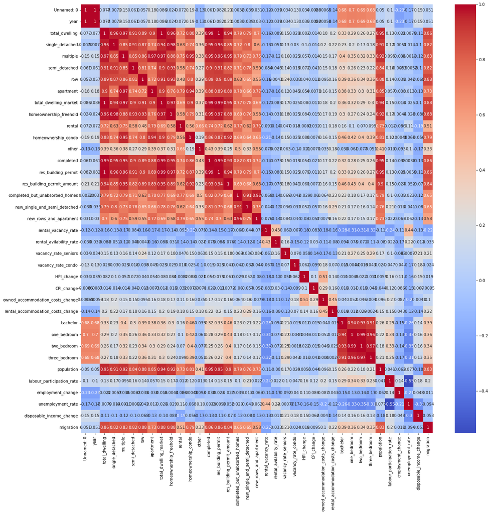

```python
#correlation matrix as ususal
import matplotlib.pyplot as plt
import seaborn as sns
plt.figure(figsize=(20,20))
sns.heatmap(canada_clean.corr(),annot=True,cmap='coolwarm')
plt.savefig('heatmap.png')
```

### Visualization

```python
from plotly.offline import download_plotlyjs, init_notebook_mode,plot, iplot
```

```python
#!pip install cufflinks
```

```python
import cufflinks as cf
cf.go_offline()
cf.set_config_file(offline=False, world_readable=True)
```

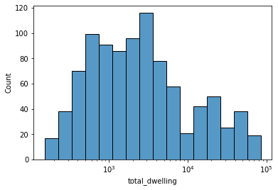

```python
#trying to plot year
sns.histplot(data=canada_clean, x="total_dwelling", log_scale=True)
```

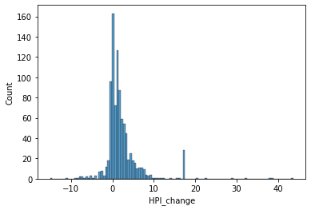

```python
sns.histplot(data=canada_clean, x="HPI_change")
```

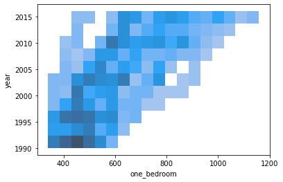

```python
#toronto_clean[''].plot(kind='box')

sns.histplot(data=canada_clean, x="one_bedroom", y="year", kde=True)
```

#### Here we can clearly see that how the Mortgage of houses with one bedroom increased over the years.

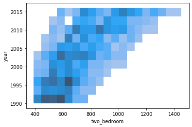

```python
sns.histplot(data=canada_clean, x="two_bedroom", y="year", kde=True)
```

#### Here we can clearly see that how the Mortgage of houses with Two bedroom increased over the years.

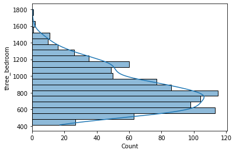

```python
#toronto_clean['three_bedroom'].plot(kind='box')
sns.histplot(data=canada_clean, y="three_bedroom", kde=True)
```

```python
#correlation of a column
def corr_of_a_column(df,column_name,how_many=None,ax=None):
    how_many = len(df)if how_many == None else how_many
    cor = df.corr()[[column_name]].sort_values(by=column_name,ascending=False)[:how_many]
    print(cor)
    sns.heatmap(cor,annot=True,cmap=sns.cubehelix_palette(start=.5,rot=-.5,as_cmap=True),ax=ax)
```

```
                                   HPI_change
HPI_change                           1.000000
owned_accommodation_costs_change     0.505373
labour_participation_rate            0.155398
disposable_income_change             0.151497
rental_accommodation_costs_change    0.141787
employment_change                    0.112912
single_detached                      0.101963
CPI_change                           0.100779
homeownership_condo                  0.088046
homeownership_freehold               0.083677
total_dwelling                       0.081583
total_dwelling_market                0.079671
res_building_permit                  0.074869
semi_detached                        0.071997
vacancy_rate_condo                   0.062029
res_building_permit_amount           0.060561
multiple                             0.057002
completed                            0.054271
apartment                            0.053945
new_single_and_semi_detached         0.052421
row                                  0.039696
year                                 0.034663
Unnamed: 0                           0.034164
two_bedroom                          0.022064
migration                            0.018983
bachelor                             0.010697
population                           0.005477
one_bedroom                          0.004474
rental                              -0.008201
three_bedroom                       -0.011302
other                               -0.021297
completed_but_unabsorbed_homes      -0.029496
vacancy_rate_seniors                -0.058142
new_rows_and_apartment              -0.080438
rental_avilability_rate             -0.118456
unemployment_rate                   -0.159414
rental_vacancy_rate                 -0.176675
```

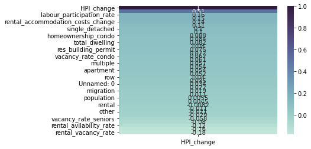

```python
corr_of_a_column(canada_clean, 'HPI_change')
```

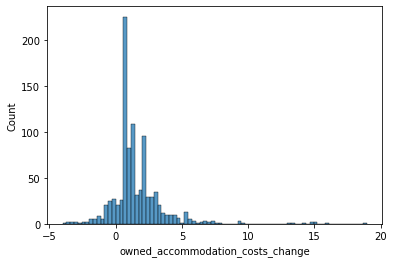

```python
#toronto_clean['owned_accommodation_costs_change'].plot(kind='hist')
sns.histplot(data=canada_clean, x="owned_accommodation_costs_change")
```

#### Most owned accomodation cost will change from -5 to 5 range.

```python
canada_clean.columns
```

```
Index(['Unnamed: 0', 'year', 'total_dwelling', 'single_detached', 'multiple',
       'semi_detached', 'row', 'apartment', 'total_dwelling_market',
       'homeownership_freehold', 'rental', 'homeownership_condo', 'other',
       'completed', 'res_building_permit', 'res_building_permit_amount',
       'completed_but_unabsorbed_homes', 'new_single_and_semi_detached',
       'new_rows_and_apartment', 'rental_vacancy_rate',
       'rental_avilability_rate', 'vacancy_rate_seniors', 'vacancy_rate_condo',
       'HPI_change', 'CPI_change', 'owned_accommodation_costs_change',
       'rental_accommodation_costs_change', 'bachelor', 'one_bedroom',
       'two_bedroom', 'three_bedroom', 'population',
       'labour_participation_rate', 'employment_change', 'unemployment_rate',
       'disposable_income_change', 'migration', 'region'],
      dtype='object')
```

```python
canada_clean.info()
```

```
<class 'pandas.core.frame.DataFrame'>
RangeIndex: 944 entries, 0 to 943
Data columns (total 38 columns):
 #   Column                             Non-Null Count  Dtype
---  ------                             --------------  -----
 0   Unnamed: 0                         944 non-null    int64
 1   year                               944 non-null    float64
 2   total_dwelling                     944 non-null    int64
 3   single_detached                    944 non-null    int64
 4   multiple                           944 non-null    int64
 5   semi_detached                      944 non-null    int64
 6   row                                944 non-null    int64
 7   apartment                          944 non-null    int64
 8   total_dwelling_market              944 non-null    int64
 9   homeownership_freehold             944 non-null    float64
```

[output cut: 30 more lines]

```python
def get_continuous_df(df):
    return df.select_dtypes(include=[np.int64, np.float64])

# Get df with columns having categorical variables
def get_categorical_df(df):
    return df.select_dtypes(include=['object'])
```

```python
continuous_df = get_continuous_df(canada_clean)
continuous_df.head()
```

|  | Unnamed: 0 | year | total_dwelling | single_detached | multiple | semi_detached | row | apartment | total_dwelling_market | homeownership_freehold | ... | bachelor | one_bedroom | two_bedroom | three_bedroom | population | labour_participation_rate | employment_change | unemployment_rate | disposable_income_change | migration |
| --- | --- | --- | --- | --- | --- | --- | --- | --- | --- | --- | --- | --- | --- | --- | --- | --- | --- | --- | --- | --- | --- |
| 0 | 0 | 1990.0 | 3297 | 2847 | 450 | 57 | 6 | 387 | 2274 | 2004.0 | ... | 310 | 418 | 524 | 608 | 1105.421 | 67.300 | 0.219444 | 7.4 | -2.669133 | -5108 |
| 1 | 1 | 1991.0 | 1950 | 1589 | 361 | 14 | 0 | 347 | 1438 | 1085.0 | ... | 318 | 424 | 531 | 630 | 1109.604 | 67.025 | -1.364064 | 8.6 | -2.669133 | -5108 |
| 2 | 2 | 1992.0 | 2310 | 1683 | 627 | 64 | 10 | 553 | 1821 | 1383.0 | ... | 324 | 434 | 545 | 644 | 1112.689 | 66.475 | -1.351685 | 9.3 | -0.326989 | -5108 |
| 3 | 3 | 1993.0 | 2425 | 1874 | 551 | 52 | 83 | 416 | 1702 | 1338.0 | ... | 327 | 435 | 550 | 652 | 1117.618 | 66.850 | 0.766782 | 9.3 | -0.453243 | -2520 |
| 4 | 4 | 1994.0 | 3197 | 2441 | 756 | 72 | 410 | 274 | 1664 | 1289.0 | ... | 329 | 440 | 551 | 645 | 1123.230 | 66.750 | 0.774181 | 8.8 | 0.161821 | -1996 |

5 rows × 37 columns

```python
categorical_df = get_categorical_df(canada_clean)
categorical_df.head()
```

|  | region |
| --- | --- |
| 0 | manitoba |
| 1 | manitoba |
| 2 | manitoba |
| 3 | manitoba |
| 4 | manitoba |

[figure not shown]

```python
def plot_base_relation(df, figsize=(20, 200)):
    columns = df.columns.tolist()
    _, axs = plt.subplots(len(columns), 4, figsize=figsize)

    for idx, column in enumerate(columns):
        # To get distribution of data
        sns.histplot(
            x=df[column],
            kde=False,
            color='#65b87b', alpha=.7,
            ax=axs[idx][0]
        )

        # To get knowledge about outliers
        sns.boxplot(
            x=df[column],
            color='#6fb9bd',
            ax=axs[idx][1]
        )

        # To get its realtion with SalePrice
        sns.scatterplot(
            x=column, y='HPI_change', data=df,
            color='#706dbd', alpha=.7, s=80,
            ax=axs[idx][2]
        )

        # To get count plot for `column`
        sns.countplot(
            x=column, data=df,
            color='#42b0f5', alpha=.7,
            ax=axs[idx][3]
        )

plot_base_relation(continuous_df)
```

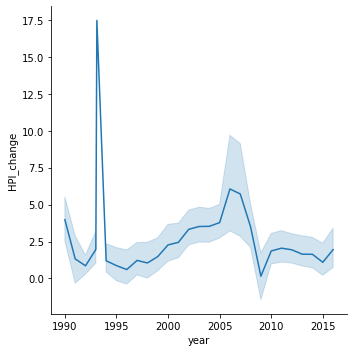

```python
sns.relplot(data=canada_clean, x="year", y="HPI_change", kind="line")
```

```python
from scipy.stats import zscore, pearsonr
```

```python
def get_corr(data_1, data_2):
    return round(pearsonr(data_1, data_2)[0], 2)


def get_corr_info_for_df(df):
    columns = df.columns.tolist()
    displayed = []
    def is_displayed(main_column, secondary_column, displayed_list):
        return any([
            True for tup in displayed_list if
            (tup[0] == main_column and tup[1] == secondary_column)
            or
            (tup[1] == main_column and tup[0] == secondary_column)
        ])


    # main column is the one for which we'll find all the corr info
    # related to secondary column
    for main_column in columns:
        for secondary_column in columns:
            if secondary_column != main_column and not is_displayed(main_column, secondary_column, displayed):
                corr = get_corr(df[main_column], df[secondary_column])
                if corr >= .7 or corr <= -.7:
                    # print only if pearson correlation is high (.7 to .9) or very high (.9 to 1)
                    print(f'{secondary_column} - {main_column}: {corr}')
                    displayed.append((main_column, secondary_column))


get_corr_info_for_df(continuous_df)
```

```
year - Unnamed: 0: 1.0
one_bedroom - Unnamed: 0: 0.7
one_bedroom - year: 0.7
single_detached - total_dwelling: 0.96
multiple - total_dwelling: 0.97
semi_detached - total_dwelling: 0.91
row - total_dwelling: 0.89
apartment - total_dwelling: 0.9
total_dwelling_market - total_dwelling: 1.0
homeownership_freehold - total_dwelling: 0.96
rental - total_dwelling: 0.72
homeownership_condo - total_dwelling: 0.88
completed - total_dwelling: 0.99
res_building_permit - total_dwelling: 1.0
res_building_permit_amount - total_dwelling: 0.94
completed_but_unabsorbed_homes - total_dwelling: 0.79
new_single_and_semi_detached - total_dwelling: 0.79
new_rows_and_apartment - total_dwelling: 0.7
population - total_dwelling: 0.95
migration - total_dwelling: 0.86
multiple - single_detached: 0.85
semi_detached - single_detached: 0.91
row - single_detached: 0.87
apartment - single_detached: 0.74
total_dwelling_market - single_detached: 0.94
homeownership_freehold - single_detached: 0.98
homeownership_condo - single_detached: 0.74
completed - single_detached: 0.95
res_building_permit - single_detached: 0.96
res_building_permit_amount - single_detached: 0.85
completed_but_unabsorbed_homes - single_detached: 0.72
new_single_and_semi_detached - single_detached: 0.8
population - single_detached: 0.91
migration - single_detached: 0.82
semi_detached - multiple: 0.85
row - multiple: 0.86
apartment - multiple: 0.97
total_dwelling_market - multiple: 0.97
homeownership_freehold - multiple: 0.88
rental - multiple: 0.75
```

[output cut: 80 more lines]

```
population - res_building_permit_amount: 0.9
migration - res_building_permit_amount: 0.84
new_single_and_semi_detached - completed_but_unabsorbed_homes: 0.91
new_rows_and_apartment - completed_but_unabsorbed_homes: 0.96
population - completed_but_unabsorbed_homes: 0.79
new_rows_and_apartment - new_single_and_semi_detached: 0.75
population - new_single_and_semi_detached: 0.76
population - new_rows_and_apartment: 0.73
one_bedroom - bachelor: 0.94
two_bedroom - bachelor: 0.93
three_bedroom - bachelor: 0.91
two_bedroom - one_bedroom: 0.99
three_bedroom - one_bedroom: 0.96
three_bedroom - two_bedroom: 0.97
migration - population: 0.83
```

#### We can find the following websites for reference:

• Canada Mortgage and Housing Corporation (CMHC): https://www.cmhc-schl.gc.ca/en/ • Statistics Canada: https://www.statcan.gc.ca/eng/start • Royal Bank of Canada (RBC): https://www.rbc.com/economics/economic-reports/housing-trends-and-affordability.html • Canadian Real Estate Association (CREA): https://www.crea.ca/